# DATA151: Bivariate Relationships

Kitada Smalley

### Learning Objectives:

Students will learn to create scatterplots and describe the relationships between two numeric variables.

### Example: Take A Hike!

#### STEP 1: Load the data:

```r
body_wgt<-c(120, 187, 109, 103, 131, 165, 158, 116)
backpack_wgt<-c(26, 30, 26, 24, 29, 35, 31, 28)

backpack_df<-data.frame(body_wgt, backpack_wgt)
```

Which variable should be the response and which should be the explantory?

```
## YOUR ANSWER HERE ##
```

#### STEP 2: Scatterplot

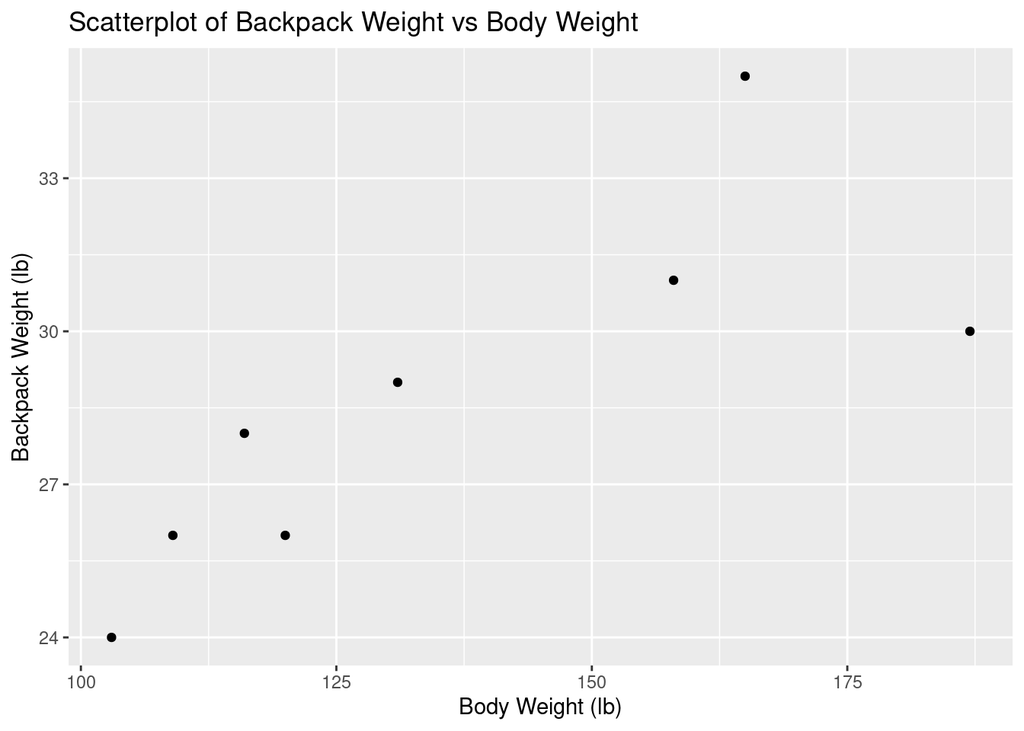

```r
library(tidyverse)

ggplot(backpack_df, aes(x=body_wgt, y=backpack_wgt))+
  geom_point()+
  xlab("Body Weight (lb)")+
  ylab("Backpack Weight (lb)")+
  ggtitle("Scatterplot of Backpack Weight vs Body Weight")
```

#### STEP 3: Describe

When looking at a scatterplot you want to be able to describe the overall pattern and for striking departures from that pattern.

You can describe the overall pattern of a scatterplot by the:

- direction – positive or negative
- form – linear or non-linear
- strength – strong (points close together) or weak (points spread out)
- outliers - an individual value that falls outside the overall pattern of the relationship

How would you describe the above scatterplot?

```
### YOUR ANSWER HERE ###
```

#### STEP 4: Correlation Coefficient

```r
cor(body_wgt, backpack_wgt)
```

```
## [1] 0.7946927
```

What happens when you switch the order of the variables?

```r
## YOU TRY IT
```

#### STEP 5: Activity

**First**: Load in the data

```r
data("anscombe")
str(anscombe)
```

```
## 'data.frame':    11 obs. of  8 variables:
##  $ x1: num  10 8 13 9 11 14 6 4 12 7 ...
##  $ x2: num  10 8 13 9 11 14 6 4 12 7 ...
##  $ x3: num  10 8 13 9 11 14 6 4 12 7 ...
##  $ x4: num  8 8 8 8 8 8 8 19 8 8 ...
##  $ y1: num  8.04 6.95 7.58 8.81 8.33 ...
##  $ y2: num  9.14 8.14 8.74 8.77 9.26 8.1 6.13 3.1 9.13 7.26 ...
##  $ y3: num  7.46 6.77 12.74 7.11 7.81 ...
##  $ y4: num  6.58 5.76 7.71 8.84 8.47 7.04 5.25 12.5 5.56 7.91 ...
```

**Directions**:

If your birthday is:

- January - March: Use variables `x1` and `y1`
- April - June: Use variables `x2` and `y2`
- July - September: Use variables `x3` and `y3`
- October - December: Use variables `x4` and `y4`

Complete the following tasks:

- Create a scatterplot and describe it
- Calculate the mean and standard deviation for both your `x` and `y` variables
- Calculate the correlation coefficient
- Compare the information you have obtained with your neighbor

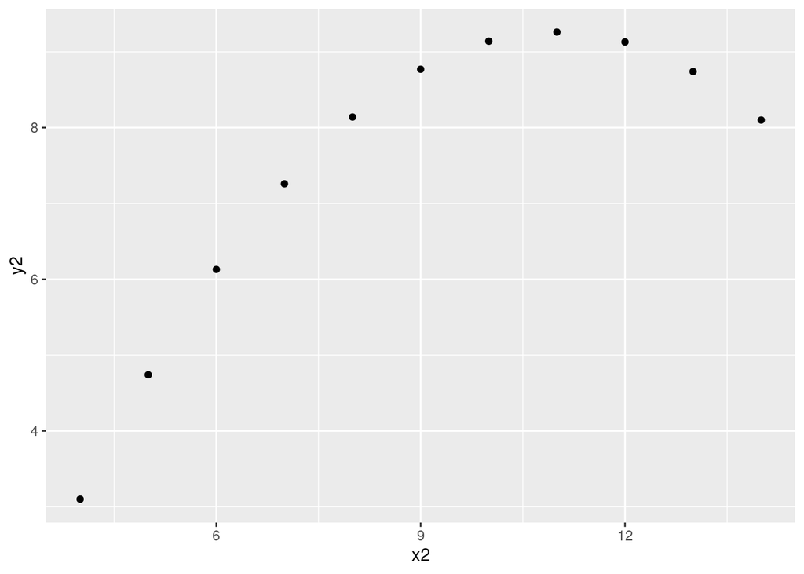

```r
## SPACE FOR YOUR WORK ##
ggplot(anscombe, aes(x2, y2))+
  geom_point()
```

#### STEP 6: Line of Best Fit

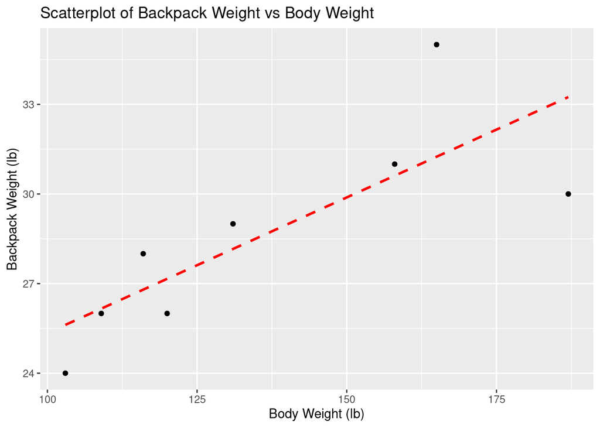

```r
ggplot(backpack_df, aes(x=body_wgt, y=backpack_wgt))+
  geom_point()+
  geom_smooth(method="lm", se=FALSE, color="red", lty=2)+
  xlab("Body Weight (lb)")+
  ylab("Backpack Weight (lb)")+
  ggtitle("Scatterplot of Backpack Weight vs Body Weight")
```

What is this line?

```r
# Y~X
# Y~X
mod<-lm(backpack_wgt~body_wgt, data=backpack_df)
summary(mod)
```

```
##
## Call:
## lm(formula = backpack_wgt ~ body_wgt, data = backpack_df)
##
## Residuals:
##     Min      1Q  Median      3Q     Max
## -3.2444 -1.2750  0.1133  0.9308  3.7532
##
## Coefficients:
##             Estimate Std. Error t value Pr(>|t|)
## (Intercept) 16.26493    3.93692   4.131  0.00614 **
## body_wgt     0.09080    0.02831   3.207  0.01844 *
## ---
## Signif. codes:  0 '***' 0.001 '**' 0.01 '*' 0.05 '.' 0.1 ' ' 1
##
## Residual standard error: 2.27 on 6 degrees of freedom
## Multiple R-squared:  0.6315, Adjusted R-squared:  0.5701
## F-statistic: 10.28 on 1 and 6 DF,  p-value: 0.01844
```